# MaxDiff TEST analysis (an example)

Danijel Kopčinović, IT Market

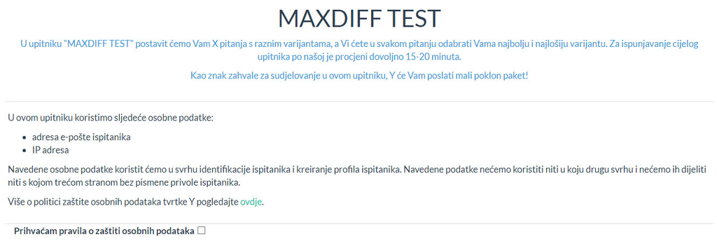

## Introduction

In this document we will present a test market research with the MaxDiff method. The research is based on the (assumed) wish of a local pizzeria to find out which new pizzas would its buyers prefer to see in its offering.

New pizzas that the respondents choose from are:

```
##  [1] miješana        povrtna         pikantna        4 vrste sira
##  [5] s tunom         ribarska        4 godišnja doba calzone
##  [9] slavonska       rukola/pršut    bolonjez        lovačka
## [13] losos           sa salamom
## 14 Levels: 4 godišnja doba 4 vrste sira bolonjez calzone losos ... slavonska
```

Except the main products (pizzas) that are in our focus, we will also take into account a possible influence of the “demographic” factors to the answers/results:

```
## $lokacija
## $lokacija$naziv
## [1] "lokacija"
##
## $lokacija$vrijednosti
## [1] "blizu pizzerije"     "daleko od pizzerije"
```

In a MaxDiff survey respondents choose the best and the worst product among a few alternatives. Let’s have a look at some products combinations that we posed as questions.

| task | items | best_choice | worst_choice |
| --- | --- | --- | --- |
| 1 | bolonjez,slavonska,miješana | ? | ? |
| 2 | pikantna,sa salamom,losos | ? | ? |
| 3 | calzone,4 godišnja doba,pikantna | ? | ? |
| 4 | miješana,pikantna,rukola/pršut | ? | ? |
| 5 | miješana,losos,4 vrste sira | ? | ? |

All combinations were divided to 3 questionnaires, each with 6 questions, each with 3 options/alternatives.

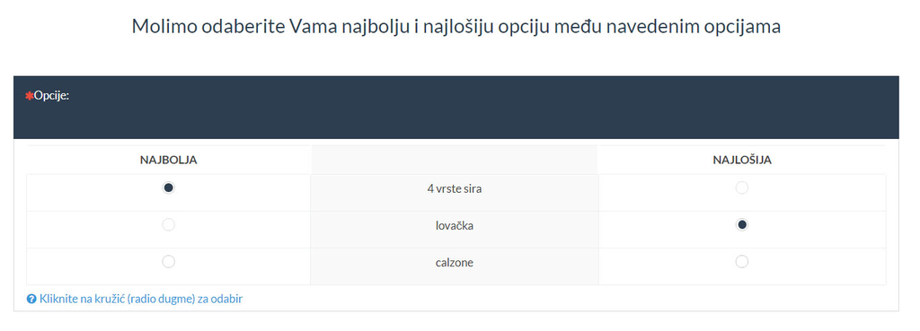

For a better estimation of the values of different products, we added a question in which a respondent expresses general positive or negative tendency to a few given products. The products given in this question are chosen related to the previous respondent’s choices, so that a span, from the pizzas most often chosen as best to the pizzas most often chosen as worst, is given. In this question products are not compared with each other but all against the so called threshold option, which can mean different things in different contexts, but generally means the point between want/don’t want, would buy/wouldn’t buy, am interested/am not interested etc. This question helps us to better level the answers of all the respondents against the threshold option and thus against each other, giving us better and more relevant product values estimates.

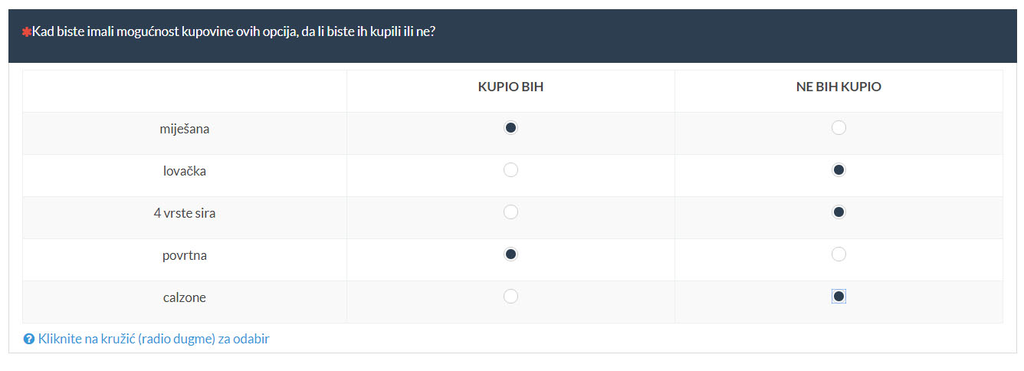

Survey results were computer generated, with certain random parameters, for 50 respondents.

## Multinomial logit model analysis

More advanced analysis includes data (respondents’ choices) modelling and then calculating the coefficients (values) for each product according to the multinomial logit model. After applying this analysis to our data, we get the following summary:

```
##                     1st Qu.        Mean    3rd Qu.
## miješana         -3.8746646 -2.80420117 -1.7045744
## povrtna          -2.8112907 -1.71682540 -0.6284795
## pikantna         -5.2835986 -4.01769175 -2.6867025
## X4.vrste.sira    -4.6844629 -3.50925539 -2.2845709
## s.tunom          -4.4945888 -3.15138503 -1.8027073
## ribarska         -0.6454911  0.31401702  1.2569757
## X4.godišnja.doba -1.9524976 -0.90343482  0.1160530
## calzone          -4.8241831 -3.63488575 -2.3907034
## slavonska        -2.5777090 -1.56500776 -0.5453987
## rukola.pršut     -6.5644197 -5.35338253 -4.0919290
## bolonjez         -1.2495140 -0.16716032  0.8920445
## lovačka          -3.1775021 -2.07759241 -0.9302135
## losos            -0.9751336  0.05567277  1.0696677
## sa.salamom       -7.7436144 -6.38989425 -4.9318665
```

If we normalize and scale all the coefficients so that the threshold option (would/would not buy) maps to the number 100, it is easier to interpret their values and corresponding ratios:

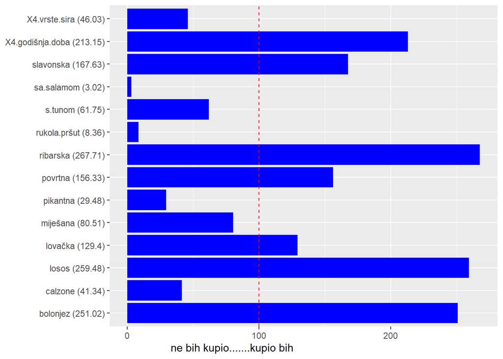

Now we can see that the most valued product is ribarska and that its value is 1.26 times more than the value of X4.godišnja.doba.

These results show the main advantages of the MaxDiff analysis compared to a simple product “ordering” from the best to the worst which is sometimes (too often :)) used for business analyses. MaxDiff shows us:

- *relations between products* - how much is each product more or less valuable to the respondents,
- product positions *related to (key!) point marking the positive/negative attitude* - would or would not buy, am or am not interested…

This way we get a complete picture of all the products from the respondents’ perspective and we can make quality business decisions.

## Products correlation analysis

Another element that we can analyze is the correlation between the products/products values.

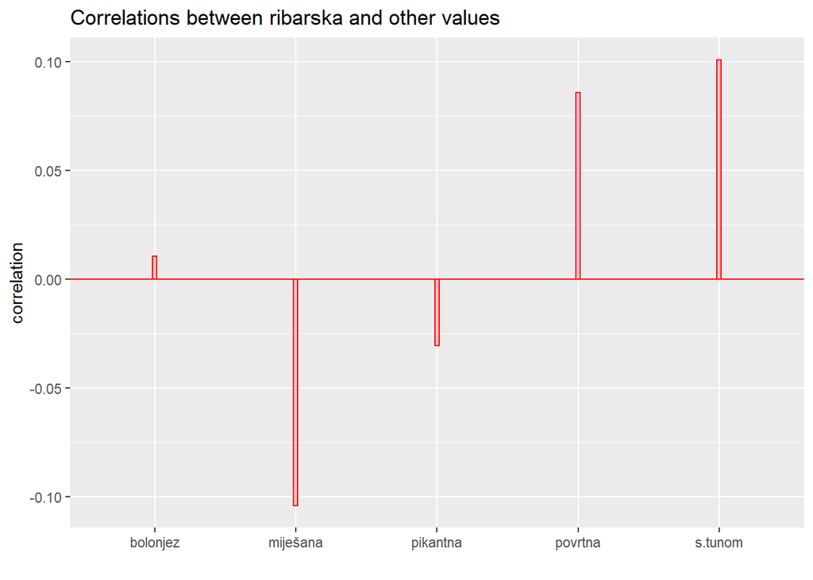

For example, in the graph shown above, we can see that *ribarska* is positively correlated with *povrtna, s.tunom, bolonjez*, and negatively correlated with *miješana, pikantna*. This means that if respondents put more value to the *ribarska* pizza, then they put more value also to *povrtna, s.tunom, bolonjez*, while they put less value to *miješana, pikantna*.

Results of the analysis and coefficients estimation is the easiest to understand with the share prediction calculation, which we will now show.

## Share prediction

Once we have all the product coefficients estimates, we can compare different product combinations and predict the sales shares. Predicted sales shares are probabilities that a certain product will be chosen/sold compared to other products in the tested combination.

As an example we will pick a combination of a few randomly selected products and calculate their predicted sales shares:

```
##         [,1]      [,2]       [,3]           [,4]      [,5]
## opcije  "povrtna" "miješana" "4 vrste sira" "s tunom" "pikantna"
## share % "35.22"   "19.78"    "13.67"        "20.45"   "10.87"
```

In the table above we can see how would respondents choose between 5 different pizzas. Each pizza gets the predicted share (percentage) in the total sales, according to the corresponding coefficients estimates.

**Most often chosen option** (among the given pizzas, not in general) is *povrtna* **with the predicted sales share 35.22%**.

## Checking the model on the existing data

With the share predictions for different products combinations, we can also test how would our model predict the choices for (some) of the combinations given in the survey:

```
##                    choice
## respondent/question true best predicted best true worst predicted worst
##                34/6         1              1          3               3
##                17/4         2              2          3               3
##                28/1         1              1          3               3
##                28/6         1              1          3               3
##                48/4         1              1          2               2
##                29/4         1              1          2               2
##                28/4         1              1          2               2
##                29/6         2              2          1               1
##                49/4         2              2          3               3
##                1/4          1              1          3               3
##                34/1         2              2          3               3
##                29/1         2              2          1               1
##                45/1         1              1          2               2
##                45/6         3              3          1               1
##                49/1         2              2          1               3
##                45/4         1              1          3               3
##                20/6         2              2          3               3
##                17/1         1              1          3               3
##                48/1         2              2          3               3
##                20/4         1              1          3               3
```

```
## [1] "Overall correct predictions:98.33%"
```

The overall prediction correctness gives us confidence that our model works well.

## Respondents segmentation

Taking into account different factors (demographic or other), we can divide the respondents into segments and then model how each segment (instead of average or individual) values the products. The number of segments we believe exists in the respondents set must be given in advance as a parameter. Assuming that there are 2 different respondents segments we build the multinomial logit model with LCA (Latent Class Analysis) and get the following summary:

```
##        miješana    povrtna  pikantna X4.vrste.sira   s.tunom   ribarska
## seg 1 -3.114903 -2.1896986 -4.775539     -3.573794 -3.957704  0.6605931
## seg 2 -2.297267 -0.9452955 -2.781204     -3.403955 -1.835812 -0.2514492
##       X4.godišnja.doba   calzone slavonska rukola.pršut  bolonjez   lovačka
## seg 1       -1.2567898 -4.519932 -1.342719    -5.581708 -0.976642 -2.571645
## seg 2       -0.3269082 -2.190863 -1.927689    -4.980852  1.153573 -1.271507
##            losos sa.salamom
## seg 1 -0.4113712  -6.010781
## seg 2  0.8176919  -7.008448
```

Since one of the goals of the segmentation is assigning each respondent to some segment (with the highest probability), let’s see this result too (the numbers given are the numbers of the respondents belonging to a certain segment):

```
## [1] "Segment 1"
##  [1]  1  3  4  6  7 11 12 16 17 19 20 23 24 25 26 27 29 30 31 32 33 35 36 41 42
## [26] 43 44 45 48 49 50
## [1] "Segment 2"
##  [1]  2  5  8  9 10 13 14 15 18 21 22 28 34 37 38 39 40 46 47
```

Respondents segmentation can also be presented graphically:

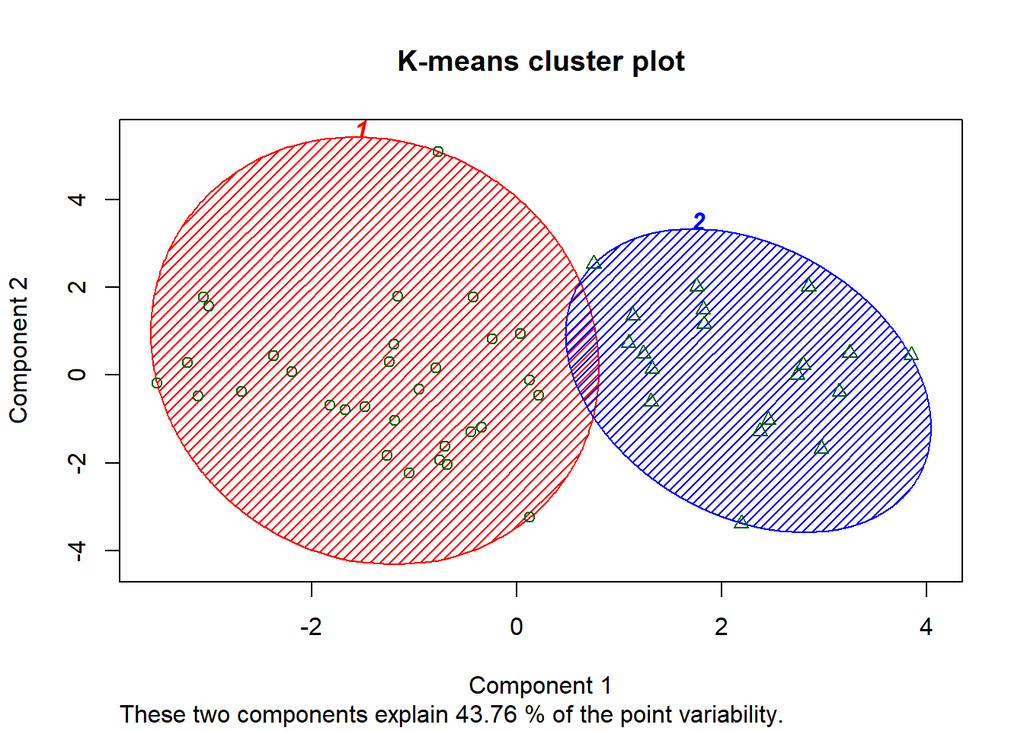

With the given segmentation we can e.g. create different products that will be the most interesting (best valued) by each segment, thus increasing buyers satisfaction and income/profit.

## TURF analysis

With an offer that contains more products we will increase the probability that at least some product will be sold. To calculate which products should be offered to achieve the highest number of sales, we can use TURF (total unduplicated reach and frequency) analysis.

Let’s assume that we want to put 3 products in an offer. For each combination/offer containing 3 products and for each respondent from our survey, we will calculate whether he would buy at least one product from the offer (reach - is he ‘reached’ with at least one product) and how many (if any) products from the offer would he buy (frequency - how many times is he ‘reached’ with the offer). The respondent’s buying decision for a product is based on the probability of sales for that product compared with the other products in the offer and the basic threshold option marking the buying/not buying boundary.

Let’s have a look at a few rows from the reach & frequency table for our products and offers (ordered decreasing by reach):

| combination | reach | freq |
| --- | --- | --- |
| 4 vrste sira, ribarska, rukola/pršut | 47 | 49 |
| miješana, ribarska, calzone | 47 | 54 |
| 4 godišnja doba, bolonjez, sa salamom | 46 | 53 |
| 4 vrste sira, calzone, losos | 46 | 51 |
| 4 vrste sira, ribarska, lovačka | 46 | 53 |
| 4 vrste sira, ribarska, sa salamom | 46 | 47 |

We can see that the offer 4 vrste sira, ribarska, rukola/pršut would reach (at least one product would be bought by) the most respondents, 47 of them, which is 94% of the total number of respondents, with a total of 49 (potential) sales.

This way we can build an offer of products that will maximize the sales.

## Conclusion

**MaxDiff analysis is a powerful tool for gaining knowledge of your customers and their values and creating the best products for them. This approach always leads to the business improvement, higher incomes and higher customer satisfaction.**

For more information contact **danijel.kopcinovic@itmarket.hr**.